# Bank Marketing – Customer Response Prediction

Group 4: Selimcan Biçer, Batuhan Karaköy, Ayşegül Uzunsoy, Yusuf Yeşilmen

2025-05-21

# Objective

- Predict whether a client subscribes to a term deposit.
- Use demographic and campaign-related features.
- Build and evaluate a predictive model using logistic regression.

# About the Dataset

- Source: Portuguese bank’s direct marketing campaigns
- Observations: 45211
- Variables: 17
- Features include:
  - Age, job, marital status, education
  - Housing and personal loan status
  - Contact type and campaign info
- **Target variable:** `y` – whether the client subscribed (yes/no)

# Presentation Roadmap

1. Exploratory Data Analysis (EDA)
2. Linear Modeling
3. Logistic Regression Modeling
4. Model Evaluation (Accuracy, ROC, AUC)
5. Marketing Recommendations

# Colnames, Glimpse and Summary

```
 [1] "age"       "job"       "marital"   "education" "default"   "balance"
 [7] "housing"   "loan"      "contact"   "day"       "month"     "duration"
[13] "campaign"  "pdays"     "previous"  "poutcome"  "y"
```

```
Rows: 45,211
Columns: 17
$ age       <int> 58, 44, 33, 47, 33, 35, 28, 42, 58, 43, 41, 29, 53, 58, 57, …
$ job       <chr> "management", "technician", "entrepreneur", "blue-collar", "…
$ marital   <chr> "married", "single", "married", "married", "single", "marrie…
$ education <chr> "tertiary", "secondary", "secondary", "unknown", "unknown", …
$ default   <chr> "no", "no", "no", "no", "no", "no", "no", "yes", "no", "no",…
$ balance   <int> 2143, 29, 2, 1506, 1, 231, 447, 2, 121, 593, 270, 390, 6, 71…
$ housing   <chr> "yes", "yes", "yes", "yes", "no", "yes", "yes", "yes", "yes"…
$ loan      <chr> "no", "no", "yes", "no", "no", "no", "yes", "no", "no", "no"…
$ contact   <chr> "unknown", "unknown", "unknown", "unknown", "unknown", "unkn…
$ day       <int> 5, 5, 5, 5, 5, 5, 5, 5, 5, 5, 5, 5, 5, 5, 5, 5, 5, 5, 5, 5, …
$ month     <chr> "may", "may", "may", "may", "may", "may", "may", "may", "may…
$ duration  <int> 261, 151, 76, 92, 198, 139, 217, 380, 50, 55, 222, 137, 517,…
$ campaign  <int> 1, 1, 1, 1, 1, 1, 1, 1, 1, 1, 1, 1, 1, 1, 1, 1, 1, 1, 1, 1, …
$ pdays     <int> -1, -1, -1, -1, -1, -1, -1, -1, -1, -1, -1, -1, -1, -1, -1, …
$ previous  <int> 0, 0, 0, 0, 0, 0, 0, 0, 0, 0, 0, 0, 0, 0, 0, 0, 0, 0, 0, 0, …
$ poutcome  <chr> "unknown", "unknown", "unknown", "unknown", "unknown", "unkn…
$ y         <chr> "no", "no", "no", "no", "no", "no", "no", "no", "no", "no", …
```

- Simple Look at the Data
- No missing values, but some variables (job, education, poutcome) include “unknown” categories.
- Numeric variables like balance and duration show skewed distributions and potential outliers.
- Skewness can affect models that assume normality (e.g., logistic regression).

```
      age            job              marital           education
 Min.   :18.00   Length:45211       Length:45211       Length:45211
 1st Qu.:33.00   Class :character   Class :character   Class :character
 Median :39.00   Mode  :character   Mode  :character   Mode  :character
 Mean   :40.94
 3rd Qu.:48.00
 Max.   :95.00
   default             balance         housing              loan
 Length:45211       Min.   : -8019   Length:45211       Length:45211
 Class :character   1st Qu.:    72   Class :character   Class :character
 Mode  :character   Median :   448   Mode  :character   Mode  :character
                    Mean   :  1362
                    3rd Qu.:  1428
                    Max.   :102127
   contact               day           month              duration
 Length:45211       Min.   : 1.00   Length:45211       Min.   :   0.0
 Class :character   1st Qu.: 8.00   Class :character   1st Qu.: 103.0
 Mode  :character   Median :16.00   Mode  :character   Median : 180.0
                    Mean   :15.81                      Mean   : 258.2
                    3rd Qu.:21.00                      3rd Qu.: 319.0
                    Max.   :31.00                      Max.   :4918.0
    campaign          pdays          previous          poutcome
 Min.   : 1.000   Min.   : -1.0   Min.   :  0.0000   Length:45211
 1st Qu.: 1.000   1st Qu.: -1.0   1st Qu.:  0.0000   Class :character
 Median : 2.000   Median : -1.0   Median :  0.0000   Mode  :character
 Mean   : 2.764   Mean   : 40.2   Mean   :  0.5803
 3rd Qu.: 3.000   3rd Qu.: -1.0   3rd Qu.:  0.0000
 Max.   :63.000   Max.   :871.0   Max.   :275.0000
      y
 Length:45211
 Class :character
 Mode  :character
```

- Quick overview of the dataset’s structure.
- It showed that the data contains 45,211 observations and 17 variables, including both numeric and categorical types.

# Target Variable: Subscription Outcome (y)

- y represents whether a client subscribed to a term deposit after the marketing campaign.
- It is a binary categorical variable with two possible values: “yes” and “no”.

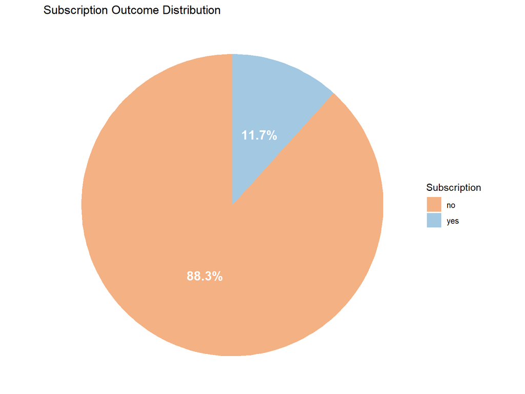

- Only about 11.7% of clients subscribed (yes), while 88.3% did not (no).
- This imbalance can bias models toward predicting the majority class (no) if not addressed properly.

# 📊 Response Rate by Job Type

- This horizontal bar chart displays the conversion (subscription) rate for each job category.
- Jobs are sorted by response rate, and a dashed vertical line represents the overall average subscription rate (~11.7%).

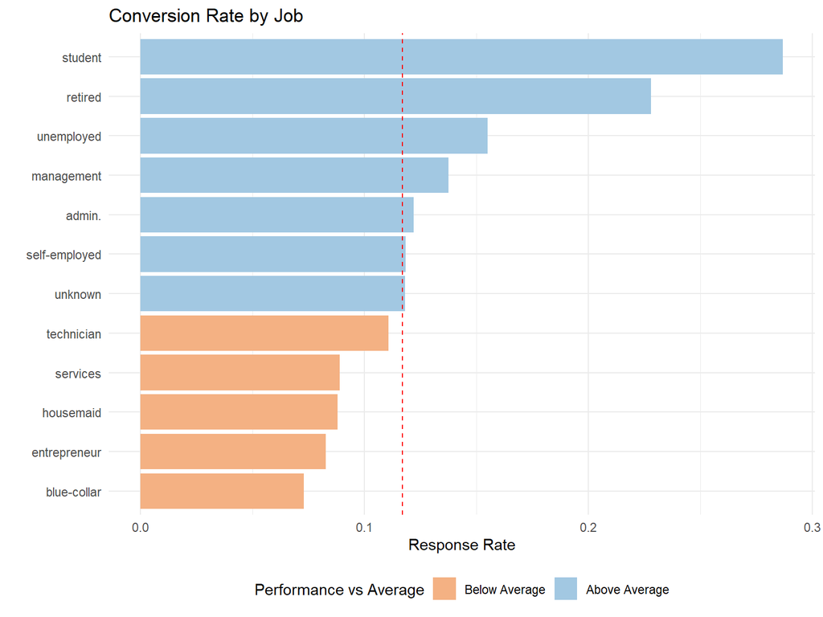

- Clients in roles like student, retired, and unemployed are more likely to subscribe, making them ideal segments to focus on in future campaigns.
- Conversely, blue-collar, entrepreneur, and housemaid roles have much lower response rates, indicating lower campaign efficiency in those groups.

# Subscription Rate by Marital Status

- This bar chart shows subscription rates across different **marital status** groups.
- Segments with **above-average rates** are shown in blue.
- The **dashed line** indicates the overall conversion conversion rate.

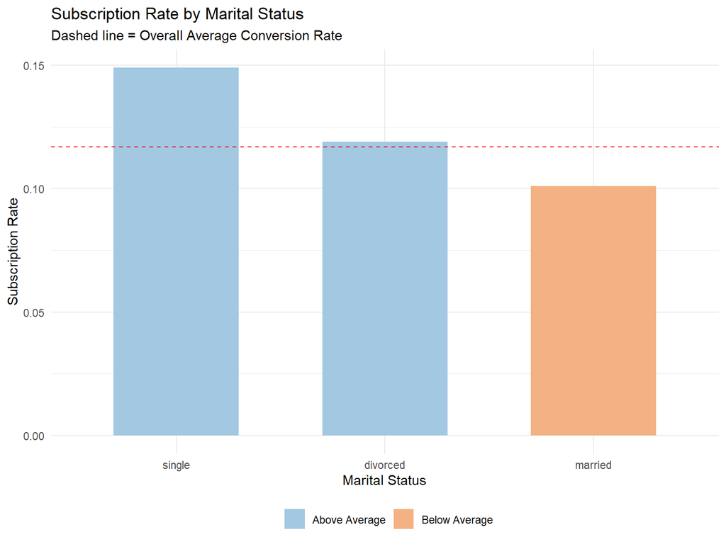

- Why We Analyzed marital?
- In marketing, marital status is commonly used for segmentation and message personalization.
- Graphs:
- Single clients have the highest conversion rate, significantly above average.
- Divorced clients are slightly above average.
- Married clients show a below-average response rate.

# Response Rate by Education Level

- This chart shows subscription rates across different **education levels**.
- Segments with **above-average subscription rates** are shown in blue.
- The **dashed line** marks the overall subscription rate across all clients.

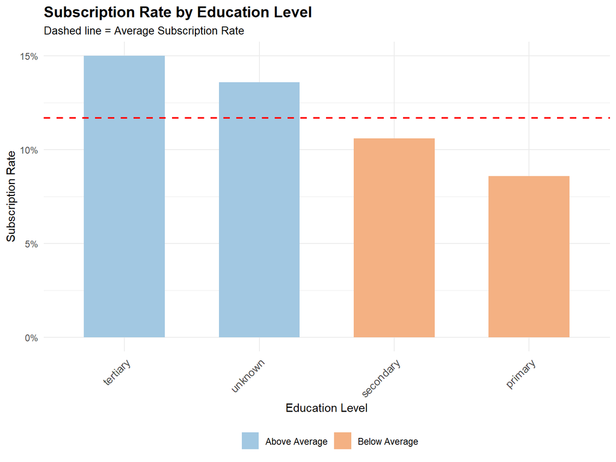

- Clients with tertiary education have the highest conversion rate, well above the average.
- The “unknown” group surprisingly also performs above average.
- Clients with secondary and primary education are below the average, with primary being the lowest.
- How to Use This Insight?
- In modeling: Include education as a categorical feature with “unknown” treated explicitly.
- In strategy: Prioritize tertiary-educated clients for high-value campaigns

# Age Distribution of Customers

- This histogram shows the overall age distribution of clients.
- It helps us detect age clusters and possible outliers.
- Can age be an informative predictor?

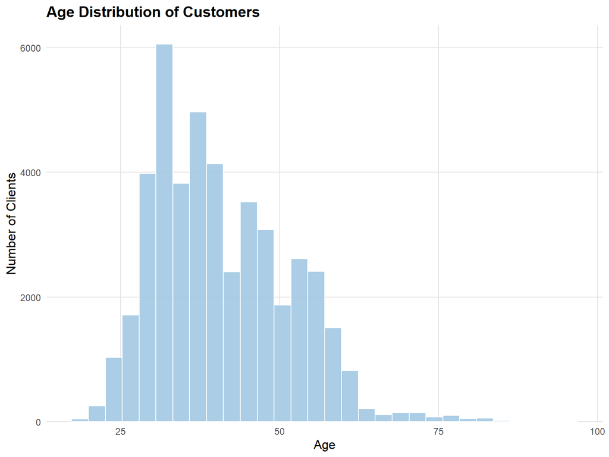

- Most clients are between 30 and 60 years old.
- There are some younger (under 25) and older (over 70) clients, but they’re fewer.
- The distribution is slightly right-skewed, suggesting more clients are in middle adulthood.

# Age Distribution by Subscription Outcome

- This violin plot shows how **age** is distributed across subscription outcomes.
- It helps us assess whether **age** influences the likelihood of subscribing.

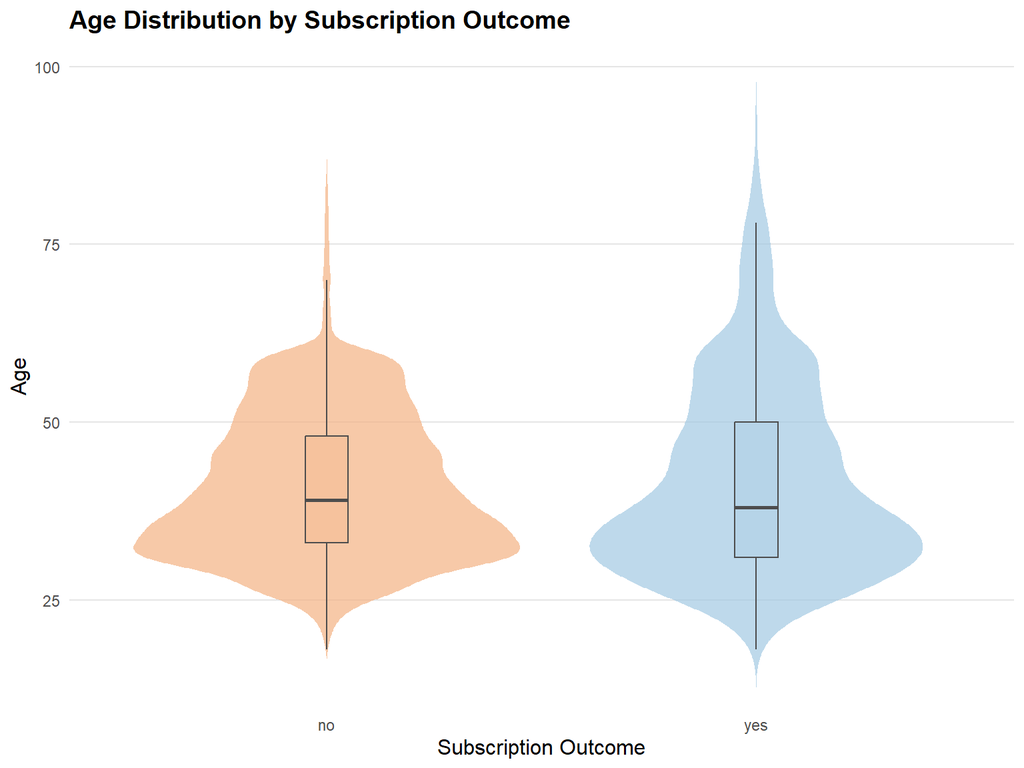

# Call Duration vs Subscription Outcome

- `duration` represents the call length in seconds.
- It’s **highly correlated** with the target variable (`y`) because longer calls often result in subscriptions.
- ⚠️ However, it’s a **post-outcome variable** — we can’t know duration before the call ends, so it must be used carefully.

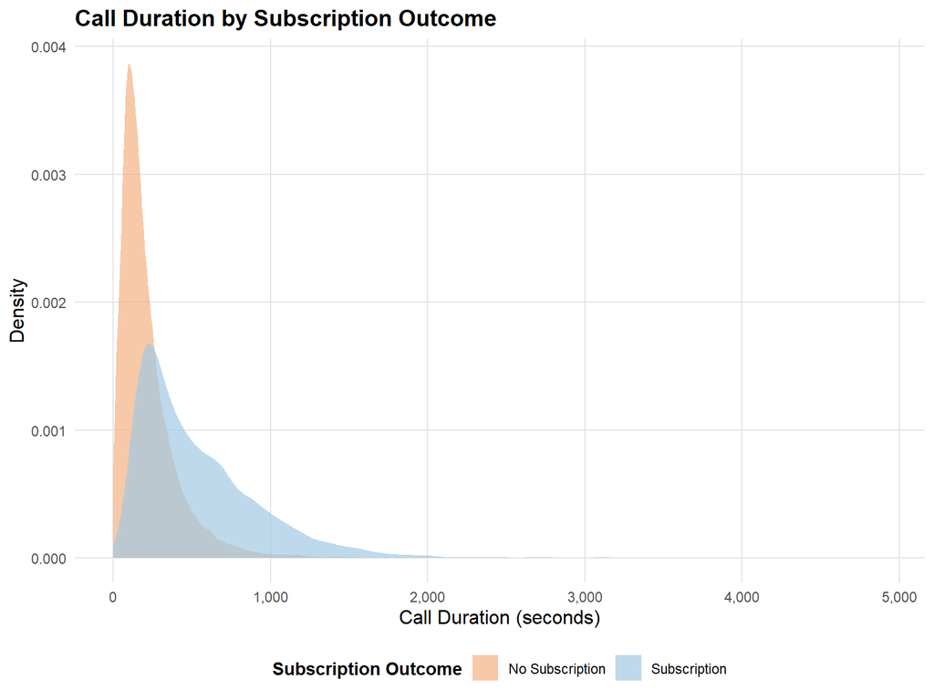

# Account Balance vs Subscription Outcome

- `balance` shows the client’s average yearly account balance in euros.
- The violin plot below compares balance distributions for subscribers vs non-subscribers.

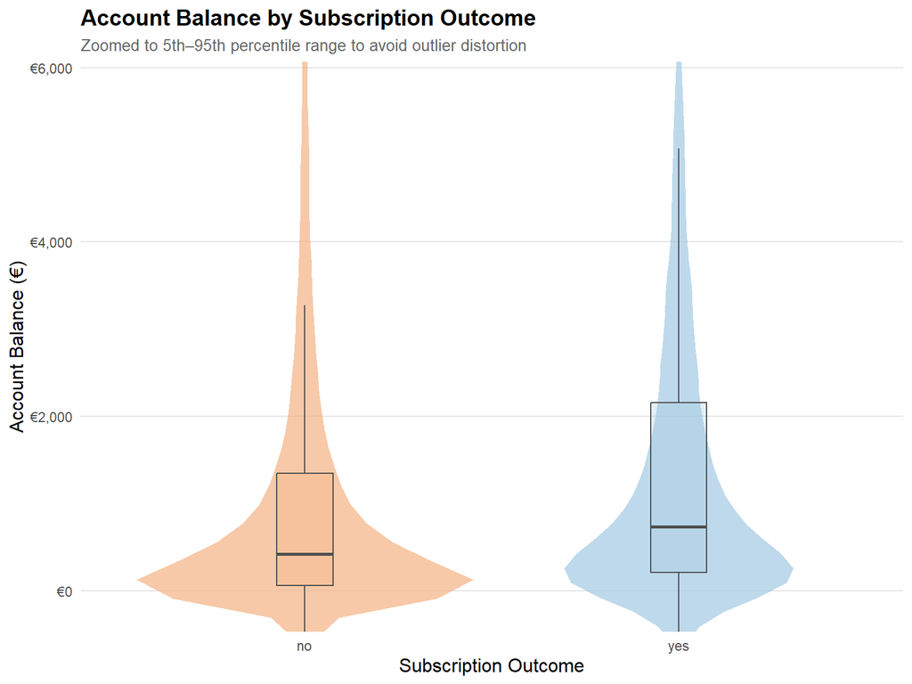

- **Clients who subscribed (`yes`) generally have higher balances** than non-subscribers.
- The **median balance** (center of the box) is **visibly higher** for the `yes` group.
- Both distributions are **positively skewed**, but the **`no` group shows more concentration at lower balances**.
- The **spread is larger for subscribers**, suggesting **greater financial diversity** among those who converted.

⚠️ Caution: Outliers & Skewness The raw balance variable includes extreme outliers, which can distort model training.

# Correlation Among Numeric Variables

- This plot shows the correlations between all numeric variables.
- It helps us detect multicollinearity and understand variable relationships.

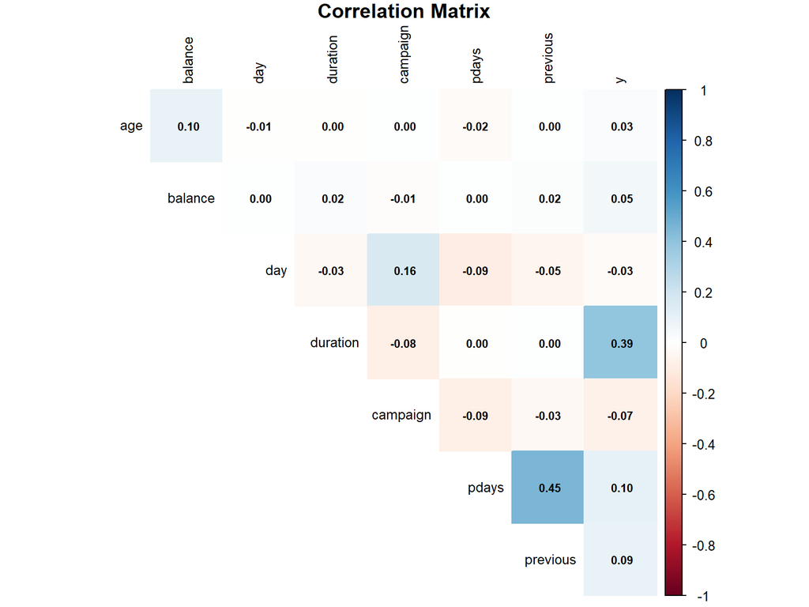

# Campaign Contact Frequency

- `campaign` shows the number of contacts during this campaign.
- High values may indicate over-contacting or customer fatigue.

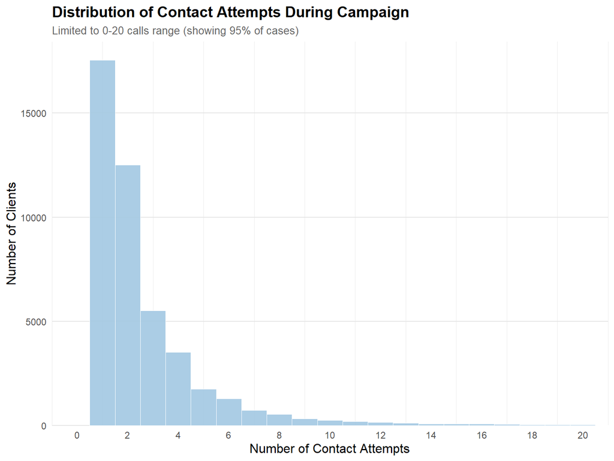

- **Most clients were contacted fewer than 5 times**, with a **sharp peak at 1 and 2 calls**.
- **Very few clients received more than 10 calls** — but those who did might represent cases of **persistent outreach or inefficient targeting**.
- The distribution is **heavily right-skewed**, indicating that **frequent contact is rare but exists**.
- ⚠️ Modeling Note:
- Due to its skewed distribution, consider log transformation or binning (e.g., 1 call, 2–3 calls, 4+ calls) before using in models.

# Linear Models – Exploratory Insight

- Although `y` is a binary variable, linear regression can still give us **initial insight** into which variable groups explain variance in subscription outcomes.
- Below, we estimate four simple linear models and compare their **R² scores**.

### Full Linear Model

```
Call:
lm(formula = y_numeric ~ ., data = bank_data_new)

Residuals:
       Min         1Q     Median         3Q        Max
-1.019e-15 -5.000e-18  1.000e-18  5.000e-18  4.645e-14

Coefficients:
                     Estimate Std. Error    t value Pr(>|t|)
(Intercept)         3.781e-17  1.150e-17  3.287e+00  0.00101 **
age                 1.132e-19  1.276e-19  8.870e-01  0.37505
jobblue-collar     -1.695e-17  3.981e-18 -4.258e+00 2.06e-05 ***
jobentrepreneur    -1.843e-17  6.612e-18 -2.787e+00  0.00531 **
jobhousemaid       -2.950e-17  7.181e-18 -4.109e+00 3.98e-05 ***
jobmanagement      -9.305e-18  4.418e-18 -2.106e+00  0.03521 *
jobretired          3.339e-17  6.181e-18  5.402e+00 6.63e-08 ***
jobself-employed   -1.996e-17  6.470e-18 -3.085e+00  0.00203 **
jobservices        -1.476e-17  4.588e-18 -3.218e+00  0.00129 **
jobstudent          6.585e-17  8.130e-18  8.100e+00 5.63e-16 ***
jobtechnician      -1.034e-17  4.018e-18 -2.574e+00  0.01006 *
jobunemployed      -7.689e-18  6.885e-18 -1.117e+00  0.26409
jobunknown         -2.233e-17  1.357e-17 -1.646e+00  0.09984 .
maritalmarried     -1.346e-17  3.360e-18 -4.007e+00 6.17e-05 ***
maritalsingle       5.649e-18  3.892e-18  1.451e+00  0.14665
educationsecondary  7.857e-18  3.333e-18  2.357e+00  0.01842 *
educationtertiary   2.375e-17  4.174e-18  5.690e+00 1.28e-08 ***
educationunknown    1.278e-17  5.940e-18  2.151e+00  0.03147 *
defaultyes         -7.652e-19  7.817e-18 -9.800e-02  0.92201
balance             8.208e-22  3.479e-22  2.359e+00  0.01831 *
housingyes         -3.914e-17  2.513e-18 -1.557e+01  < 2e-16 ***
loanyes            -2.247e-17  2.901e-18 -7.745e+00 9.78e-15 ***
contacttelephone   -9.215e-18  4.406e-18 -2.091e+00  0.03650 *
contactunknown     -7.544e-17  3.569e-18 -2.114e+01  < 2e-16 ***
day                 1.007e-18  1.439e-19  6.997e+00 2.65e-12 ***
monthaug           -4.940e-17  5.281e-18 -9.355e+00  < 2e-16 ***
monthdec            1.092e-16  1.567e-17  6.969e+00 3.23e-12 ***
monthfeb           -6.836e-18  6.188e-18 -1.105e+00  0.26928
monthjan           -9.591e-17  7.354e-18 -1.304e+01  < 2e-16 ***
monthjul           -5.390e-17  5.054e-18 -1.067e+01  < 2e-16 ***
monthjun            1.919e-17  5.995e-18  3.201e+00  0.00137 **
monthmar            2.400e-16  1.100e-17  2.182e+01  < 2e-16 ***
monthmay           -2.292e-17  4.903e-18 -4.674e+00 2.96e-06 ***
monthnov           -5.779e-17  5.455e-18 -1.059e+01  < 2e-16 ***
monthoct            1.372e-16  9.209e-18  1.490e+01  < 2e-16 ***
monthsep            1.446e-16  1.020e-17  1.418e+01  < 2e-16 ***
duration            4.462e-19  4.431e-21  1.007e+02  < 2e-16 ***
campaign           -1.415e-18  3.522e-19 -4.018e+00 5.89e-05 ***
pdays              -5.983e-20  2.230e-20 -2.683e+00  0.00730 **
previous            1.019e-18  5.328e-19  1.913e+00  0.05581 .
poutcomeother       2.563e-17  6.049e-18  4.237e+00 2.27e-05 ***
poutcomesuccess     3.933e-16  6.981e-18  5.634e+01  < 2e-16 ***
poutcomeunknown    -1.350e-17  6.673e-18 -2.023e+00  0.04304 *
yyes                1.000e+00  3.845e-18  2.601e+17  < 2e-16 ***
---
Signif. codes:  0 '***' 0.001 '**' 0.01 '*' 0.05 '.' 0.1 ' ' 1

Residual standard error: 2.195e-16 on 45167 degrees of freedom
Multiple R-squared:      1, Adjusted R-squared:      1
F-statistic: 2.255e+33 on 43 and 45167 DF,  p-value: < 2.2e-16
```

**Intercept (~0):**

- The intercept is very close to zero (3.78e-17), which means the baseline prediction (when all variables are zero) is nearly 0.
- In real life, this value doesn’t have practical meaning, since no client can have all features as zero. It mainly helps set the model’s starting point.

**Significant Job Types:**

- Some job categories strongly affect the probability of subscription.
- jobstudent (+): Students are more likely to say “yes”.
- jobretired (+): Retired people also have a higher chance.
- jobblue-collar, jobself-employed, jobservices (-): These jobs are associated with a lower chance.
- These effects are statistically significant (p < 0.01) and could reflect real differences in behavior across job types.

**Month Effects:**

- Some months show very strong patterns:
- monthmar, monthoct, monthsep: Very high positive effect — clients are much more likely to subscribe in these months.
- monthjan, monthjul, monthnov, monthaug: Negative effect — lower success rates in these months.
- This suggests that timing of the campaign plays an important role in client decisions.

**Call Duration (0.000446):**

- Duration is the most powerful predictor.
- Longer calls = higher chance of success.
- This is highly significant and makes sense: more talk time means better engagement.

**R² = 1.0 (100%):**

- This model explains all the variation in the data — which seems too perfect.
- This usually means there is a problem like data leakage.

**Problem Detected – yyes:**

- The variable yyes has a coefficient of 1.0, meaning the model is predicting y_numeric using itself.
- This is a serious mistake. It makes the model useless in practice.

### Model 1 – Demographic Variables

```
Call:
lm(formula = y_numeric ~ age, data = bank_data_new)

Residuals:
    Min      1Q  Median      3Q     Max
-0.1582 -0.1216 -0.1140 -0.1094  0.9005

Coefficients:
             Estimate Std. Error t value Pr(>|t|)
(Intercept) 0.0858166  0.0060184   14.26  < 2e-16 ***
age         0.0007614  0.0001423    5.35 8.83e-08 ***
---
Signif. codes:  0 '***' 0.001 '**' 0.01 '*' 0.05 '.' 0.1 ' ' 1

Residual standard error: 0.3213 on 45209 degrees of freedom
Multiple R-squared:  0.0006328, Adjusted R-squared:  0.0006107
F-statistic: 28.63 on 1 and 45209 DF,  p-value: 8.826e-08
```

**Intercept (0.0858):**

- When age = 0, the predicted probability of subscription is 8.58%.
- Note: This is purely theoretical (clients cannot be age 0). The intercept helps anchor the model but has no real-world meaning here.

**Age Coefficient (0.00076):**

For every 1-year increase in age, the probability of subscribing increases by 0.076% (a negligible effect).

- Example: A 30-year-old has a predicted subscription probability of 0.0858 + (30 × 0.00076) = 10.86%.
- While statistically significant (*p* < 0.001), this effect is practically meaningless due to its tiny magnitude.

**R² = 0.00063 (0.063%):**

- The model explains only 0.063% of the variation in subscriptions.
- This is extremely weak—age alone is irrelevant for predicting subscriptions.

**Residual Standard Error (0.321):**

- Predictions are off by ±32 percentage points on average—far too high for practical use.

**F-test (*p* = 8.83e-08):**

- The relationship is statistically significant, but only due to the huge sample size (n=45,211).
- Key Insight: Statistical significance ≠ practical importance.

### Model 2 – Campaign Activity Variables

**Why these variables?**  
We included `campaign`, `pdays`, and `previous` because they directly measure **customer engagement** during the marketing process:

- **`campaign`**: How many times the client was contacted during this campaign.
- **`pdays`**: Days since the client was last contacted (in a previous campaign).
- **`previous`**: Number of times the client was contacted in earlier campaigns.

These are behavior-based features — not personal demographics — and are often used to assess **marketing pressure, timing**, and **persistence**.

```
Call:
lm(formula = y_numeric ~ campaign + pdays + previous, data = bank_data_new)

Residuals:
     Min       1Q   Median       3Q      Max
-2.42206 -0.11470 -0.10797 -0.09449  1.09414

Coefficients:
              Estimate Std. Error t value Pr(>|t|)
(Intercept)  1.217e-01  2.137e-03   56.95   <2e-16 ***
campaign    -6.737e-03  4.856e-04  -13.88   <2e-16 ***
pdays        2.284e-04  1.686e-05   13.55   <2e-16 ***
previous     8.196e-03  7.304e-04   11.22   <2e-16 ***
---
Signif. codes:  0 '***' 0.001 '**' 0.01 '*' 0.05 '.' 0.1 ' ' 1

Residual standard error: 0.3186 on 45207 degrees of freedom
Multiple R-squared:  0.0176,    Adjusted R-squared:  0.01754
F-statistic:   270 on 3 and 45207 DF,  p-value: < 2.2e-16
```

**campaign coefficient = -0.0067**  
→ A negative relationship: more contact attempts in this campaign slightly **decrease** the likelihood of subscription.  
→ This may indicate **diminishing returns** or even customer fatigue.

**pdays coefficient = +0.00023**  
→ Clients who were contacted recently (lower pdays) are **less likely** to subscribe.  
→ Those contacted after more time tend to convert more, suggesting the benefit of **spaced outreach**.

Model Fit Evaluation

**R² = 0.0176**  
→ Only **1.76%** of the variance is explained by these campaign variables.  
→ This is **very low**, indicating the model has **poor explanatory power**.

**Residual Std. Error = 0.3186**  
→ High residual error confirms that these variables **alone** are **not sufficient** to predict subscriptions reliably.

### Model 3 – Financial Status & Credit Risk

**Why these variables?**  
This model includes financial background indicators that may influence a client’s likelihood to invest:

- **`balance`**: Yearly average account balance — a proxy for savings potential.
- **`loan`**: Whether the client has a personal loan.
- **`housing`**: Whether they have a housing loan.
- **`default`**: History of credit default.

These variables are directly tied to a client’s **financial capacity and risk profile**, which can shape their decision to commit to a term deposit.

```
Call:
lm(formula = y_numeric ~ balance + loan + housing + default,
    data = bank_data_new)

Residuals:
    Min      1Q  Median      3Q     Max
-0.5742 -0.1688 -0.0856 -0.0817  1.0113

Coefficients:
              Estimate Std. Error t value Pr(>|t|)
(Intercept)  1.687e-01  2.470e-03  68.308  < 2e-16 ***
balance      3.970e-06  4.940e-07   8.037  9.4e-16 ***
loanyes     -5.100e-02  4.097e-03 -12.449  < 2e-16 ***
housingyes  -8.686e-02  3.013e-03 -28.824  < 2e-16 ***
defaultyes  -3.919e-02  1.127e-02  -3.476  0.00051 ***
---
Signif. codes:  0 '***' 0.001 '**' 0.01 '*' 0.05 '.' 0.1 ' ' 1

Residual standard error: 0.3174 on 45206 degrees of freedom
Multiple R-squared:  0.02501,   Adjusted R-squared:  0.02492
F-statistic: 289.9 on 4 and 45206 DF,  p-value: < 2.2e-16
```

**balance coefficient = +0.00000397**  
→ Slight positive effect: clients with higher balances are **more likely** to subscribe.  
→ Effect is statistically significant but **very small in magnitude**.

**loan = yes → -0.051**  
→ Clients with personal loans are **less likely** to subscribe. Possibly due to financial constraints.

**housing = yes → -0.087**  
→ Having a housing loan is negatively associated with subscription, indicating **lower investment capacity**.

**default = yes → -0.039**  
→ Past defaulters are **less responsive**, though this effect is weaker than loan or housing.

Model Fit Evaluation

**R² = 0.025**  
→ The model explains only **2.5%** of the variation in the target variable.  
→ This is a **very weak model** in terms of predictive power.

**Residual Std. Error = 0.3174**  
→ High error remains — the model is far from capturing subscription behavior accurately.

### Model 4 – Temporal and Contact Info

**Why these variables?**  
We used `contact`, `month`, and `day` because they capture **when** and **how** the client was reached, which may impact responsiveness:

- **`contact`**: Method used to reach the client (cellular, telephone, unknown).
- **`month`**: The month when the contact was made — seasonality effect.
- **`day`**: Day of the month (1–31) — to check timing sensitivity.

```
Call:
lm(formula = y_numeric ~ contact + month + day, data = bank_data_new)

Residuals:
     Min       1Q   Median       3Q      Max
-0.52891 -0.11505 -0.10067 -0.01753  1.03121

Coefficients:
                   Estimate Std. Error t value Pr(>|t|)
(Intercept)       0.1947108  0.0066405  29.322  < 2e-16 ***
contacttelephone -0.0274479  0.0060297  -4.552 5.33e-06 ***
contactunknown   -0.1262973  0.0046539 -27.138  < 2e-16 ***
monthaug         -0.0864558  0.0068959 -12.537  < 2e-16 ***
monthdec          0.2755904  0.0218158  12.633  < 2e-16 ***
monthfeb         -0.0263170  0.0085349  -3.083  0.00205 **
monthjan         -0.0968317  0.0101916  -9.501  < 2e-16 ***
monthjul         -0.0998670  0.0068030 -14.680  < 2e-16 ***
monthjun          0.0123276  0.0082538   1.494  0.13529
monthmar          0.3266768  0.0152147  21.471  < 2e-16 ***
monthmay         -0.0571930  0.0068379  -8.364  < 2e-16 ***
monthnov         -0.0934202  0.0075011 -12.454  < 2e-16 ***
monthoct          0.2520711  0.0127008  19.847  < 2e-16 ***
monthsep          0.2803825  0.0140542  19.950  < 2e-16 ***
day               0.0002428  0.0001972   1.231  0.21828
---
Signif. codes:  0 '***' 0.001 '**' 0.01 '*' 0.05 '.' 0.1 ' ' 1

Residual standard error: 0.3078 on 45196 degrees of freedom
Multiple R-squared:  0.08288,   Adjusted R-squared:  0.08259
F-statistic: 291.7 on 14 and 45196 DF,  p-value: < 2.2e-16
```

**contactunknown = -0.126**  
→ Clients contacted via unknown channels are **much less likely** to subscribe.

**contacttelephone = -0.027**  
→ Traditional landline outreach performs **worse** than cellular (reference).

**month effects:**  
→ **December (+0.27)**, **March (+0.33)**, **October (+0.25)**, and **September (+0.28)** are associated with **much higher conversion rates**.  
→ In contrast, **July (-0.10)**, **January (-0.097)**, and **August (-0.086)** show **significantly lower** performance.

**day = not significant (p = 0.218)**  
→ The exact day of the month **does not significantly affect** subscription outcome.

Model Fit Evaluation

**R² = 0.083**  
→ The model explains about **8.3%** of the variance in subscription.  
→ Better than campaign or financial models, but still **limited** in predictive power.

**Residual Std. Error = 0.3078**  
→ Consistent with prior models — confirms that **substantial variation remains unexplained**.

### R² Comparison Across Models

R² Comparison of Linear Models

| Model | R_Squared |
| --- | --- |
| Demographic (Model 1) | 0.0006 |
| Campaign Activity (Model 2) | 0.0176 |
| Financial Status (Model 3) | 0.0250 |
| Contact & Timing (Model 4) | 0.0829 |

### **Summary – Why Linear Regression Falls Short**

| **Issue** | **Why It’s a Problem** |
| --- | --- |
| Binary Target | Linear model assumes continuity |
| Invalid Predictions | Can output values < 0 or > 1 |
| No Class Probabilities | Doesn’t estimate likelihood of “yes” |
| Misleading Metrics | R² doesn’t tell us real classification performance |
| Poor in Decision-Making | No clear threshold for class decision |

Linear Model Review

- Although we used linear regression for exploratory purposes, it’s not suitable for binary classification tasks like ours.
- It doesn’t model probabilities, can produce invalid outputs, and provides metrics that don’t reflect true model performance.
- We instead rely on logistic regression, SVM, and random forest, which are designed for binary outcomes and decision boundaries.”

Let’s now move on to logistic regression for proper binary classification.

# Model 1: Logistic Regression – Initial Setup

## 🔍 Objective

The goal of this model is to predict whether a client subscribes to a term deposit based on various features such as demographics, campaign interactions, and financial history. Since the target variable (`y`) is binary (`yes`/`no`), logistic regression is a suitable classification method.

## ⚙️ Why Use Cross-Validation?

Instead of a single train-test split, we applied 10-fold cross-validation (CV) to ensure more reliable and generalizable results.

- **Stability:** Each data point is used for both training and validation.
- **Bias Reduction:** Less susceptible to overfitting than a single split.
- **Better Evaluation:** Performance metrics (e.g., ROC, accuracy) are averaged across 10 folds.

## 📦 Model Implementation

[output not shown]

## ✅ Summary

Logistic regression provides a statistically sound and interpretable model, especially useful for understanding how different predictors affect the probability of subscription. Cross-validation further strengthens this approach by reducing variance and providing a more honest assessment of performance.

```
Generalized Linear Model

45211 samples
   16 predictor
    2 classes: 'no', 'yes'

No pre-processing
Resampling: Cross-Validated (10 fold)
Summary of sample sizes: 40689, 40690, 40691, 40690, 40690, 40690, ...
Resampling results:

  ROC        Sens      Spec
  0.9066801  0.975402  0.3452447
```

Model Summary

### Key Performance Metrics

[output not shown]

# Interpreting Model Coefficients

```
       (Intercept)                age   `jobblue-collar`    jobentrepreneur
              0.08               1.00               0.73               0.70
      jobhousemaid      jobmanagement         jobretired `jobself-employed`
              0.60               0.85               1.29               0.74
       jobservices         jobstudent      jobtechnician      jobunemployed
              0.80               1.47               0.84               0.84
        jobunknown     maritalmarried      maritalsingle educationsecondary
              0.73               0.84               1.10               1.20
 educationtertiary   educationunknown         defaultyes            balance
              1.46               1.28               0.98               1.00
        housingyes            loanyes   contacttelephone     contactunknown
              0.51               0.65               0.85               0.20
               day           monthaug           monthdec           monthfeb
              1.01               0.50               2.00               0.86
          monthjan           monthjul           monthjun           monthmar
              0.28               0.44               1.57               4.90
          monthmay           monthnov           monthoct           monthsep
              0.67               0.42               2.41               2.40
          duration           campaign              pdays           previous
              1.00               0.91               1.00               1.01
     poutcomeother    poutcomesuccess    poutcomeunknown
              1.23               9.89               0.91
```

- Key Interpretations:

### Demographic & Job Titles

| Variable | Odds Ratio | Interpretation |
| --- | --- | --- |
| `jobstudent` | 1.47 | Students are 47% more likely to subscribe. |
| `jobretired` | 1.29 | Retired individuals are 29% more likely to subscribe. |
| `jobhousemaid` | 0.60 | Housemaids are 40% less likely to subscribe. |
| `jobentrepreneur` | 0.70 | Entrepreneurs are 30% less likely to subscribe. |
| `jobblue-collar` | 0.73 | Blue-collar workers are 27% less likely to subscribe. |

### Education

| Variable | Odds Ratio | Interpretation |
| --- | --- | --- |
| `educationtertiary` | 1.46 | Tertiary education increases odds by 46%. |
| `educationsecondary` | 1.20 | Secondary education increases odds by 20%. |
| `educationunknown` | 1.28 | Unknown education still increases odds by 28%. |

### Financial Status

| Variable | Odds Ratio | Interpretation |
| --- | --- | --- |
| `housingyes` | 0.51 | 49% less likely to subscribe if client has a housing loan. |
| `loanyes` | 0.65 | Personal loan holders are 35% less likely to subscribe. |
| `balance` | 1.00 | Balance has no meaningful effect. |

### Contact Method & Month

| Variable | Odds Ratio | Interpretation |
| --- | --- | --- |
| `contactunknown` | 0.20 | Significantly lowers odds of subscription. |
| `contacttelephone` | 0.85 | Less effective than mobile contact (baseline). |
| `monthmar` | 4.90 | March contact increases odds nearly 5x. |
| `monthdec` | 2.00 | December is also highly effective. |
| `monthsep` | 2.40 | September shows strong performance. |
| `monthjan` | 0.28 | Very weak month for conversion. |

### Campaign History

| Variable | Odds Ratio | Interpretation |
| --- | --- | --- |
| `poutcomesuccess` | 9.89 | Previous success boosts odds nearly 10x. |
| `poutcomeother` | 1.23 | Mild positive influence. |
| `poutcomeunknown` | 0.91 | Slightly lowers chances of subscription. |

- Most influential variables: poutcomesuccess, monthmar, jobstudent, educationtertiary, and housingyes.
- This interpretation helps marketers and business analysts target their efforts more effectively .

# Model Comparison: Full vs Reduced Model

- Purpose:
- To compare a full logistic regression model with a reduced one and see if we can simplify without losing performance.

```
[1] 0.9066801
```

```
[1] 0.7208428
```

# Model Performance: Accuracy & Confusion Matrix

- Purpose:
- To evaluate the logistic regression model using a 0.5 threshold and examine its raw accuracy and prediction breakdown.

```
[1] 13562
```

```
[1] 13562
```

```
      Predicted
Actual     0     1
     0 11696   280
     1  1020   566
```

```
[1] 90.41
```

| **Term** | **Count** | **Description** |
| --- | --- | --- |
| True Negative (TN) | 11696 | The model correctly predicted a client would not subscribe. |
| False Positive (FP) | 280 | The model incorrectly predicted subscription for a non-subscriber. |
| False Negative (FN) | 1020 | The model missed actual subscribers, predicting “no”. |
| True Positive (TP) | 566 | The model correctly identified actual subscribers. |

- Accuracy: 90.41%
- This means the model correctly predicted the outcome in 90% of all cases.
- However, caution is needed:
- The dataset is imbalanced — most clients said “no”.
- Therefore, even if the model mostly predicts “no”, it can still achieve high accuracy.
- This makes accuracy a potentially misleading metric in imbalanced classification tasks.

# Precision, Recall, and F1 Score

- Purpose:
- To go beyond accuracy and evaluate model performance in detecting the minority class (“yes”).
- Accuracy can be misleading, especially with imbalanced classes.
- Precision, Recall, and F1 Score provide deeper evaluation of model performance.

```
Confusion Matrix and Statistics

          Reference
Prediction    no   yes
       no  11696  1028
       yes   280   558

               Accuracy : 0.9036
                 95% CI : (0.8985, 0.9085)
    No Information Rate : 0.8831
    P-Value [Acc > NIR] : 1.318e-14

                  Kappa : 0.4129

 Mcnemar's Test P-Value : < 2.2e-16

            Sensitivity : 0.35183
            Specificity : 0.97662
         Pos Pred Value : 0.66587
         Neg Pred Value : 0.91921
             Prevalence : 0.11694
         Detection Rate : 0.04114
   Detection Prevalence : 0.06179
      Balanced Accuracy : 0.66422

       'Positive' Class : yes
```

- Interpretation:

| **Metric** | **Value** | **Interpretation** |
| --- | --- | --- |
| Accuracy | 90.36% | The model correctly predicted 90.36% of all cases. Seems strong but may be misleading due to class imbalance. |
| Kappa | 0.4129 | Indicates moderate agreement between predictions and actuals beyond chance. |
| Sensitivity (Recall) | 35.18% | Only 35% of actual subscribers were correctly predicted — many false negatives. |
| Specificity | 97.66% | Very good at identifying non-subscribers. |
| Positive Predictive Value (Precision) | 66.59% | When the model predicts “Yes,” it is correct ~67% of the time. |
| Negative Predictive Value | 91.92% | When the model predicts “No,” it’s correct ~92% of the time. |
| Balanced Accuracy | 66.42% | Average of sensitivity and specificity — useful when classes are imbalanced. |

# Model Performance: ROC Curve & AUC

- Purpose:
- To evaluate the model’s ranking ability — how well it separates “yes” from “no” across different thresholds.
- The ROC curve shows the trade-off between True Positive Rate (TPR) and False Positive Rate (FPR).
- AUC (Area Under the Curve) tells us how well the model separates the classes.

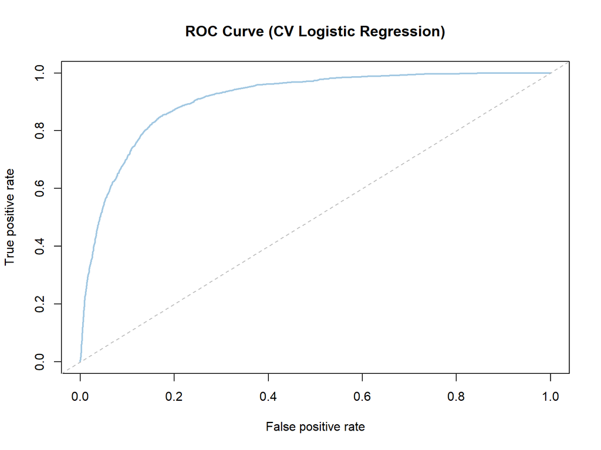

```
[1] 0.9087577
```

• AUC closer to 1 → better model • AUC < 0.7 → poor discrimination • This tells us how confidently the model ranks predictions — not just accuracy

- Interpretation:
- The AUC is high (~0.90), which means the model does a great job distinguishing between classes, even if the default threshold isn’t ideal.
  - Insights:
- We may consider adjusting the decision threshold (e.g., 0.3 instead of 0.5) to trade off precision and recall, depending on business goals.

# Model 2: Support Vector Machine (Radial Kernel)

- Purpose:
- To evaluate a Support Vector Machine model and see if it captures non-linear relationships missed by logistic regression.
- We now build an SVM model using a **radial kernel** with the `e1071` package.
- This model captures non-linear patterns and returns class probabilities.

# SVM (Radial) – Performance Evaluation

- Let’s check AUC and classification metrics for the SVM model.

```
Confusion Matrix and Statistics

          Reference
Prediction    No   Yes
       No  11749  1126
       Yes   227   460

               Accuracy : 0.9002
                 95% CI : (0.8951, 0.9052)
    No Information Rate : 0.8831
    P-Value [Acc > NIR] : 1.076e-10

                  Kappa : 0.3595

 Mcnemar's Test P-Value : < 2.2e-16

            Sensitivity : 0.29004
            Specificity : 0.98105
         Pos Pred Value : 0.66958
         Neg Pred Value : 0.91254
             Prevalence : 0.11694
         Detection Rate : 0.03392
   Detection Prevalence : 0.05066
      Balanced Accuracy : 0.63554

       'Positive' Class : Yes
```

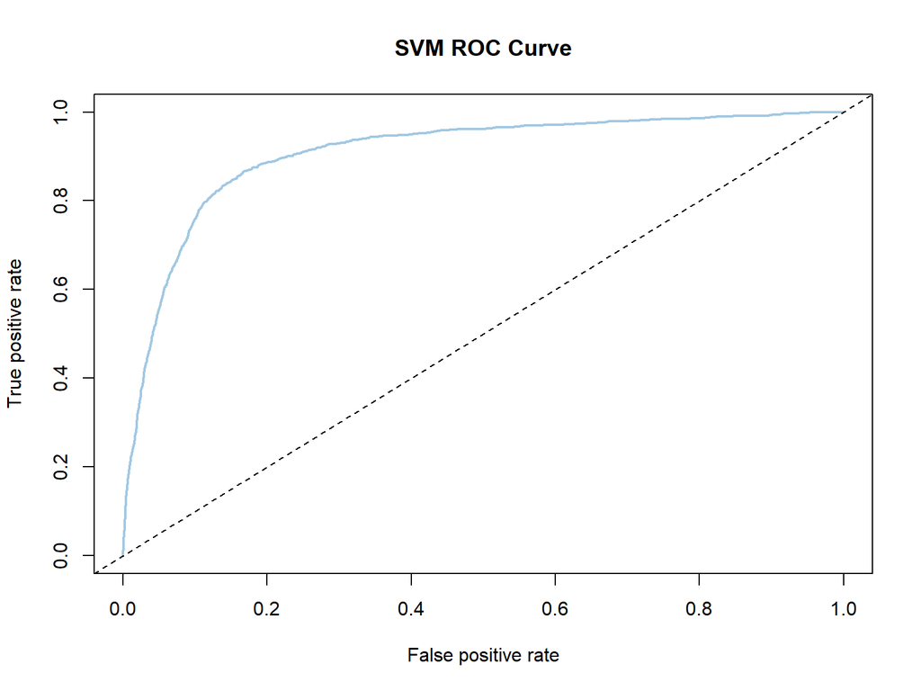

```
AUC: 0.9069758
```

# Model 3: Random Forest

- We now try a third model using the **Random Forest** algorithm.
- RF is an ensemble method based on multiple decision trees.
- It is often very effective for classification tasks.

```
      Predicted
Actual     0     1
   No  11622   354
   Yes   919   667
```

```
[1] 90.61
```

- Let’s evaluate how well Random Forest ranks predictions.

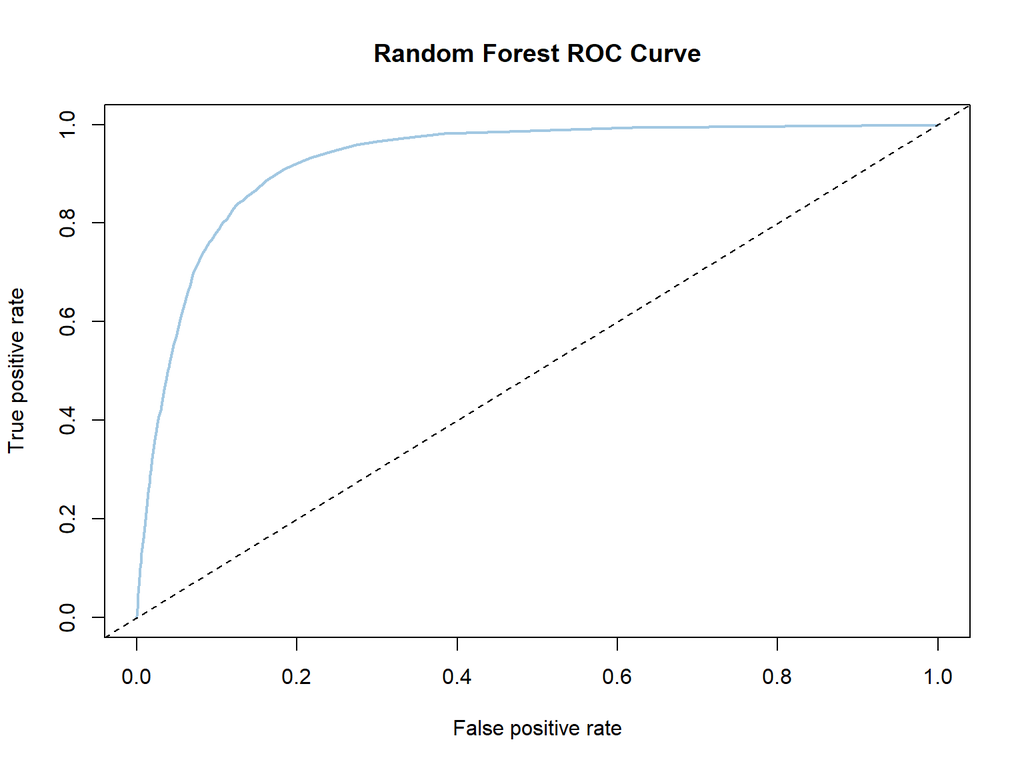

```
[1] 0.9279942
```

# Random Forest: Feature Importance

- RF provides a ranking of variable importance.
- This is valuable for marketing decisions.

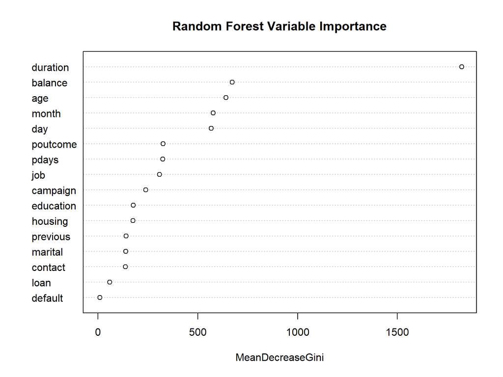

• The most important features can guide segmentation and targeting strategies.

[output not shown]

# Model Comparison Summary

- Let’s summarize the performance of all three models.
- Metrics: **Accuracy** and **AUC Score**
- Purpose:
- To summarize the performance of all three models (Logistic, SVM, RF) across Accuracy and AUC.

```
[1] 0.9044059
```

```
NULL
```

Model Performance Comparison: Accuracy and AUC

| Model | Accuracy | AUC |
| --- | --- | --- |
| Logistic Regression | 90.41 | 0.909 |
| Support Vector Machine | 90.02 | 0.907 |
| Random Forest | 90.61 | 0.928 |

• Logistic Regression is interpretable and statistically sound — especially useful for communication with non-technical stakeholders. • SVM showed strong performance with a smooth decision boundary and a competitive AUC score. • Random Forest achieved high accuracy and offers feature importance insights — helpful for segmentation strategy.

Final model choice depends on your priorities: • Use Logistic Regression if interpretability matters most. • Use SVM if nonlinear relationships dominate. • Use Random Forest if predictive performance is the top priority.

- Interpretation:
- All models perform well, but trade-offs exist: • Logistic: best for transparency • SVM: strong boundary detection • RF: highest raw accuracy and feature insights
  - Insights:
  - Model choice depends on the business goal — whether you value interpretability, prediction power, or feature understanding more.

# ✅ Final Conclusions & Strategic Marketing Recommendations

🔍 Key Takeaways • Our logistic regression model is statistically significant and supported by strong performance metrics.

• Several predictors stand out as key drivers of subscription behavior:

• Job Role: Students and retirees are significantly more likely to subscribe.

• Education Level: Clients with tertiary education show higher engagement.

• Marital Status: Single clients are more responsive than married ones.

• Previous Outcome: Past campaign success is a powerful indicator of future conversion.

# Overall Model Performance

• Accuracy: 90.41%

• AUC Score: 0.909

• Classification Quality: Outstanding

→ Indicates the model has strong discriminatory power and separates responders from non-responders effectively.

# 💡 Marketing Strategy Recommendations

### ✅ Target High-Potential Segments

- Focus marketing efforts on customer groups with higher conversion potential:

  • 🎯 Students and retirees (response rates above 20%)

  • 🎓 Clients with tertiary education

  • 📱 Clients contacted via cellular phone

  • 🔁 Clients who had a successful outcome in previous campaigns

These segments are statistically more likely to respond and should be prioritized in future outreach, content personalization, and retargeting strategies.

### 🚫 Reconsider Lower-Performing Segments

Deprioritize or redesign campaigns for groups with consistently lower response rates:

• 👷 Blue-collar and housemaid occupations

• 🏫 Clients with only primary education

• 💍 Married clients, who show below-average engagement

Reducing resource allocation toward these groups can improve campaign efficiency and allow better ROI optimization.

# 📌 Final Thoughts

• Predictive modeling is not just about forecasting — it’s about enabling smarter decisions.

• By leveraging model insights, marketing teams can transition from broad outreach to data-driven segmentation, improving both efficiency and effectiveness.